# Project - Bank Churn Prediction- Updated - Final

## Import Required Libraries

```python
import warnings
warnings.filterwarnings('ignore')
import tensorflow as tf
```

```python
import pandas as pd
import numpy as np
from sklearn.model_selection import train_test_split
import tensorflow as tf
from sklearn import preprocessing
from tensorflow.keras.models import Sequential
from tensorflow.keras.layers import Dense, Dropout
from sklearn.metrics import accuracy_score, confusion_matrix, precision_score, recall_score, f1_score, precision_recall_curve, auc
import matplotlib.pyplot as plt
from tensorflow.keras import optimizers
from sklearn.decomposition import PCA
import seaborn as sns
import keras
import tensorflow as tf
from keras import backend as K
from keras.models import Sequential
from keras.layers import Dense, Dropout
from keras.optimizers import Adam
```

## Reading the Data and Feature Elimination

### Importing & Reviewing the Data

```python
data = pd.read_csv('bank.csv')
```

```python
data.head()
```

|  | RowNumber | CustomerId | Surname | CreditScore | Geography | Gender | Age | Tenure | Balance | NumOfProducts | HasCrCard | IsActiveMember | EstimatedSalary | Exited |
| --- | --- | --- | --- | --- | --- | --- | --- | --- | --- | --- | --- | --- | --- | --- |
| 0 | 1 | 15634602 | Hargrave | 619 | France | Female | 42 | 2 | 0.00 | 1 | 1 | 1 | 101348.88 | 1 |
| 1 | 2 | 15647311 | Hill | 608 | Spain | Female | 41 | 1 | 83807.86 | 1 | 0 | 1 | 112542.58 | 0 |
| 2 | 3 | 15619304 | Onio | 502 | France | Female | 42 | 8 | 159660.80 | 3 | 1 | 0 | 113931.57 | 1 |
| 3 | 4 | 15701354 | Boni | 699 | France | Female | 39 | 1 | 0.00 | 2 | 0 | 0 | 93826.63 | 0 |
| 4 | 5 | 15737888 | Mitchell | 850 | Spain | Female | 43 | 2 | 125510.82 | 1 | 1 | 1 | 79084.10 | 0 |

```python
data.shape
```

```
(10000, 14)
```

```python
data.info()
```

```
<class 'pandas.core.frame.DataFrame'>
RangeIndex: 10000 entries, 0 to 9999
Data columns (total 14 columns):
 #   Column           Non-Null Count  Dtype
---  ------           --------------  -----
 0   RowNumber        10000 non-null  int64
 1   CustomerId       10000 non-null  int64
 2   Surname          10000 non-null  object
 3   CreditScore      10000 non-null  int64
 4   Geography        10000 non-null  object
 5   Gender           10000 non-null  object
 6   Age              10000 non-null  int64
 7   Tenure           10000 non-null  int64
 8   Balance          10000 non-null  float64
 9   NumOfProducts    10000 non-null  int64
 10  HasCrCard        10000 non-null  int64
 11  IsActiveMember   10000 non-null  int64
 12  EstimatedSalary  10000 non-null  float64
 13  Exited           10000 non-null  int64
dtypes: float64(2), int64(9), object(3)
memory usage: 1.1+ MB
```

```python
# review the statistical summary of the data.
data.describe().T
```

|  | count | mean | std | min | 25% | 50% | 75% | max |
| --- | --- | --- | --- | --- | --- | --- | --- | --- |
| RowNumber | 10000.0 | 5.000500e+03 | 2886.895680 | 1.00 | 2500.75 | 5.000500e+03 | 7.500250e+03 | 10000.00 |
| CustomerId | 10000.0 | 1.569094e+07 | 71936.186123 | 15565701.00 | 15628528.25 | 1.569074e+07 | 1.575323e+07 | 15815690.00 |
| CreditScore | 10000.0 | 6.505288e+02 | 96.653299 | 350.00 | 584.00 | 6.520000e+02 | 7.180000e+02 | 850.00 |
| Age | 10000.0 | 3.892180e+01 | 10.487806 | 18.00 | 32.00 | 3.700000e+01 | 4.400000e+01 | 92.00 |
| Tenure | 10000.0 | 5.012800e+00 | 2.892174 | 0.00 | 3.00 | 5.000000e+00 | 7.000000e+00 | 10.00 |
| Balance | 10000.0 | 7.648589e+04 | 62397.405202 | 0.00 | 0.00 | 9.719854e+04 | 1.276442e+05 | 250898.09 |
| NumOfProducts | 10000.0 | 1.530200e+00 | 0.581654 | 1.00 | 1.00 | 1.000000e+00 | 2.000000e+00 | 4.00 |
| HasCrCard | 10000.0 | 7.055000e-01 | 0.455840 | 0.00 | 0.00 | 1.000000e+00 | 1.000000e+00 | 1.00 |
| IsActiveMember | 10000.0 | 5.151000e-01 | 0.499797 | 0.00 | 0.00 | 1.000000e+00 | 1.000000e+00 | 1.00 |
| EstimatedSalary | 10000.0 | 1.000902e+05 | 57510.492818 | 11.58 | 51002.11 | 1.001939e+05 | 1.493882e+05 | 199992.48 |
| Exited | 10000.0 | 2.037000e-01 | 0.402769 | 0.00 | 0.00 | 0.000000e+00 | 0.000000e+00 | 1.00 |

• It is very difficult to interpret some of the stats from the summary, given that they are in exponential format. This is due to having the customer ID as well as other unneccessay vairables included. We will look to remove some of these variables and take another look at the statistical summary after doing so

### Feature Elimination

The purpose of this analysis is to build a neural network classifier to determine customers will leave the bank in the next 6 months. Given this, various features are not required for the purpose of this analysis. These include:

1. Row Number - the index already accounts for this, so we can drop this row
2. Customer ID - we can drop this variable given that it is just an ID representing the specific individual.
3. Suranme - the surname of the individual will not assit in determining if an individual will leave the bank.

Surname is also of 'object' data type. In order to proceed and implement this into a nerural network we would need to use one hot encoding to numerically determine their class. This would in turn lead to an excessive amount of columns/variables for the analysis. I do not consider these variables to be key in predicting as to whether an individual will leave the bank or not. Given this, I will drop these variables.

```python
# drop variables that have been outlined above
data.drop(['RowNumber','CustomerId','Surname'],axis=1,inplace=True)
data.head()
```

|  | CreditScore | Geography | Gender | Age | Tenure | Balance | NumOfProducts | HasCrCard | IsActiveMember | EstimatedSalary | Exited |
| --- | --- | --- | --- | --- | --- | --- | --- | --- | --- | --- | --- |
| 0 | 619 | France | Female | 42 | 2 | 0.00 | 1 | 1 | 1 | 101348.88 | 1 |
| 1 | 608 | Spain | Female | 41 | 1 | 83807.86 | 1 | 0 | 1 | 112542.58 | 0 |
| 2 | 502 | France | Female | 42 | 8 | 159660.80 | 3 | 1 | 0 | 113931.57 | 1 |
| 3 | 699 | France | Female | 39 | 1 | 0.00 | 2 | 0 | 0 | 93826.63 | 0 |
| 4 | 850 | Spain | Female | 43 | 2 | 125510.82 | 1 | 1 | 1 | 79084.10 | 0 |

```python
data.isna().sum()
```

```
CreditScore        0
Geography          0
Gender             0
Age                0
Tenure             0
Balance            0
NumOfProducts      0
HasCrCard          0
IsActiveMember     0
EstimatedSalary    0
Exited             0
dtype: int64
```

```python
# lets check duplicate observations
data.duplicated().sum()
```

```
0
```

```python
# review the statistical summary of the data.
data.describe().T
```

|  | count | mean | std | min | 25% | 50% | 75% | max |
| --- | --- | --- | --- | --- | --- | --- | --- | --- |
| CreditScore | 10000.0 | 650.528800 | 96.653299 | 350.00 | 584.00 | 652.000 | 718.0000 | 850.00 |
| Age | 10000.0 | 38.921800 | 10.487806 | 18.00 | 32.00 | 37.000 | 44.0000 | 92.00 |
| Tenure | 10000.0 | 5.012800 | 2.892174 | 0.00 | 3.00 | 5.000 | 7.0000 | 10.00 |
| Balance | 10000.0 | 76485.889288 | 62397.405202 | 0.00 | 0.00 | 97198.540 | 127644.2400 | 250898.09 |
| NumOfProducts | 10000.0 | 1.530200 | 0.581654 | 1.00 | 1.00 | 1.000 | 2.0000 | 4.00 |
| HasCrCard | 10000.0 | 0.705500 | 0.455840 | 0.00 | 0.00 | 1.000 | 1.0000 | 1.00 |
| IsActiveMember | 10000.0 | 0.515100 | 0.499797 | 0.00 | 0.00 | 1.000 | 1.0000 | 1.00 |
| EstimatedSalary | 10000.0 | 100090.239881 | 57510.492818 | 11.58 | 51002.11 | 100193.915 | 149388.2475 | 199992.48 |
| Exited | 10000.0 | 0.203700 | 0.402769 | 0.00 | 0.00 | 0.000 | 0.0000 | 1.00 |

### Summary Overview

Reviewing the data helped us gain some initial insight:

• Looking at the data info, there does not look to be any null values, as there are 10,000 entries across all the variables.

• The isna() function helped confirm this for us.

• There are no duplicates within the data.

• Referring to the statistical summary of the refinned data set, there does not appear to be much of a variance between the mean and the median between a lot of our variables. The Balance feature does look to have a mean value considerably less than the mean. This will result in a left skew in the distribution of this variable.

• Credit Scors also appears to has some outliers, as the min is considerable less than the first quartile. This will lead to a left skew in the distribution.

• Number of products has a min value of 1, implying that all customers within the dataset have at least one account with the bank.

• HasCrCard and IsActiveMemeber are binary variables as they take a value of either 1 or 0.

## Perform an Exploratory Data Analysis on the data

```python
# Checking for the number of distinct categories or classes i.e. left the bank or not...
data['Exited'].nunique()
```

```
2
```

• As expected there are just 2 classes for the dependent variable i.e. whether the customer has churned or not.

```python
#checking the percentage of each class in the dataset

(data.Exited.value_counts())/(data.Exited.count())
```

```
0    0.7963
1    0.2037
Name: Exited, dtype: float64
```

• This would be expected, as in general the majority of customers would stay at a bank. However, 20% of customers have left the bank i.e. 1 in 5 customers, which could be perceived to be quite high. This ties into the reasoning behind this anaylsis i.e. the bank are looking to be able to predict customers that will leave within the next 6 months and identify means by which they can reduce this number.

#### Observe the amount of Balance from Customers that left

```python
print("*********Churned Customers:************\n")
print("Total Balance of Churned Customers")
print(data.Balance[data.Exited == 1].sum())
print("Mean Balance of Churned Customers")
print(data.Balance[data.Exited == 1].mean())
print("Compare to Customers that Stayed:")
print("Total Balance of Customers that Stayed")
print(data.Balance[data.Exited == 0].sum())
print("Mean Balance of Customers that Stayed")
print(data.Balance[data.Exited == 0].mean())
```

[output not shown]

• The mean balance for customers that left is actually higher than the mean balance of customers that stayed.

• Overall this would imply a loss of income for the bank.

### Univatiate Analysis

• Univariate analysis will help us gain some insight on the single variables within the data.

```python
# the following is a function that will allow us to easily develop boxplots and histograms for some of the numerical variables.

def histogram_boxplot(feature, figsize=(15, 10), bins=None):
    """Boxplot and histogram combined
    feature: 1-d feature array
    figsize: size of fig (default (9,8))
    bins: number of bins (default None / auto)
    """
    f2, (ax_box2, ax_hist2) = plt.subplots(
        nrows=2,  # Number of rows of the subplot grid= 2
        sharex=True,  # x-axis will be shared among all subplots
        gridspec_kw={"height_ratios": (0.25, 0.75)},
        figsize=figsize,
    )  # creating the 2 subplots
    sns.boxplot(
        feature, ax=ax_box2, showmeans=True, color="violet"
    )  # boxplot will be created and a star will indicate the mean value of the column
    sns.distplot(
        feature, kde=F, ax=ax_hist2, bins=bins, color="orange"
    ) if bins else sns.distplot(
        feature, kde=False, ax=ax_hist2, color="tab:cyan"
    )  # For histogram
    ax_hist2.axvline(
        np.mean(feature), color="purple", linestyle="--"
    )  # Add mean to the histogram
    ax_hist2.axvline(
        np.median(feature), color="black", linestyle="-"
    )  # Add median to the histogram
```

### Observation on Credit Score, Balance and Estimate Salary

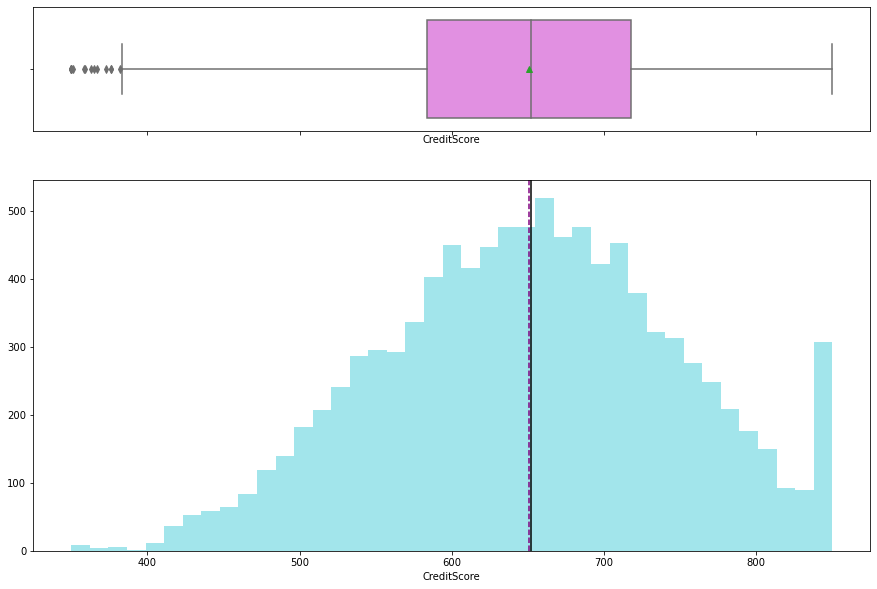

```python
histogram_boxplot(data["CreditScore"])
```

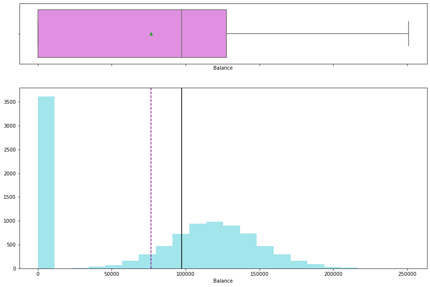

```python
histogram_boxplot(data["Balance"])
```

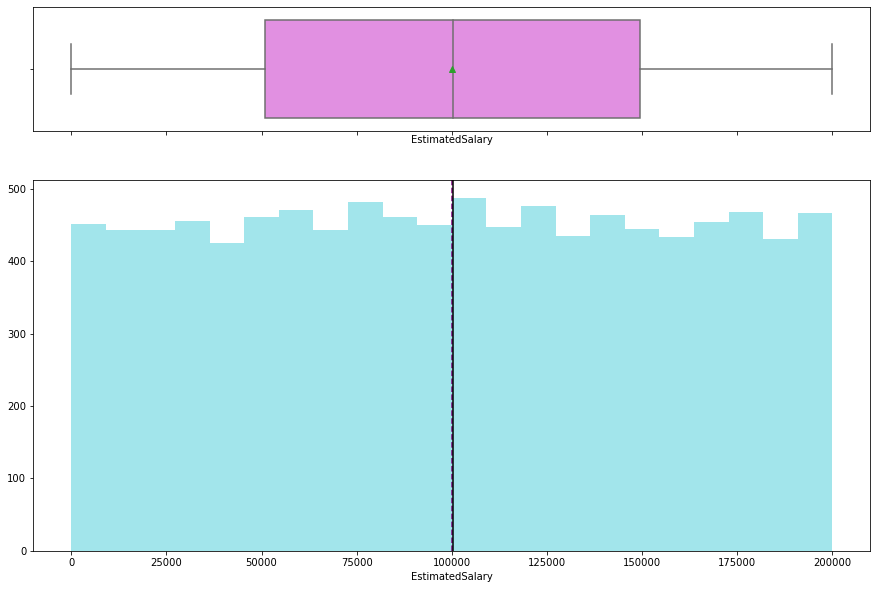

```python
histogram_boxplot(data["EstimatedSalary"])
```

```python
# Function to create barplots that indicate percentage for each category.
# This will help provide observations of some of the categorical data types.

def perc_on_bar(plot, feature):
    """
    plot
    feature: categorical feature
    the function won't work if a column is passed in hue parameter
    """
    total = len(feature)  # length of the column
    for p in ax.patches:
        percentage = "{:.1f}%".format(
            100 * p.get_height() / total
        )  # percentage of each class of the category
        x = p.get_x() + p.get_width() / 2 - 0.05  # width of the plot
        y = p.get_y() + p.get_height()  # hieght of the plot
        ax.annotate(percentage, (x, y), size=12)  # annotate the percantage
    plt.show()  # show the plot
```

### Observations of NumOfProducts, Has Card and IsActive Member

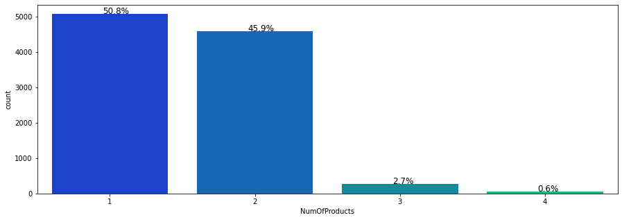

```python
plt.figure(figsize=(15,5))
ax = sns.countplot(data["NumOfProducts"],palette='winter')
perc_on_bar(ax,data["NumOfProducts"])
```

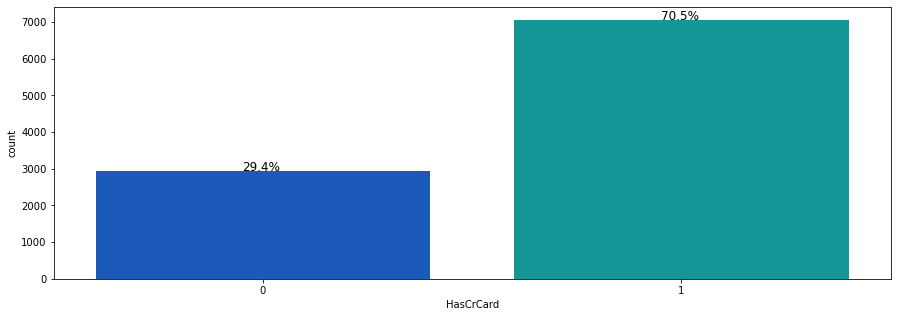

```python
plt.figure(figsize=(15,5))
ax = sns.countplot(data["HasCrCard"],palette='winter')
perc_on_bar(ax,data["HasCrCard"])
```

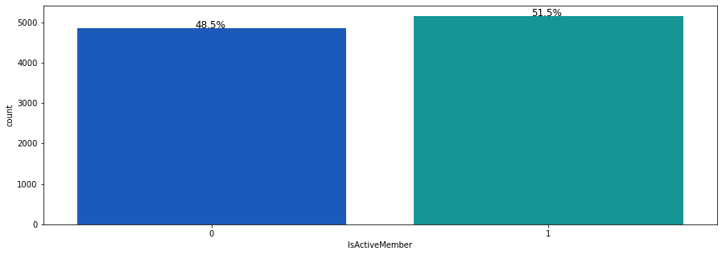

```python
plt.figure(figsize=(15,5))
ax = sns.countplot(data["IsActiveMember"],palette='winter')
perc_on_bar(ax,data["IsActiveMember"])
```

### Bivariate Analysis

```python
## Function to plot stacked bar charts
def stacked_plot(x):
    sns.set(palette="nipy_spectral")
    tab1 = pd.crosstab(x, data["Exited"], margins=True)
    print(tab1)
    print("-" * 120)
    tab = pd.crosstab(x, data['Exited'], normalize="index")
    tab.plot(kind="bar", stacked=True, figsize=(10, 5))
    plt.legend(loc='upper center', bbox_to_anchor=(0.5, 1.03), ncol=2)
    plt.show()
```

### Churned Customer vs Gender

```
Exited     0     1    All
Gender
Female  3404  1139   4543
Male    4559   898   5457
All     7963  2037  10000
------------------------------------------------------------------------------------------------------------------------
```

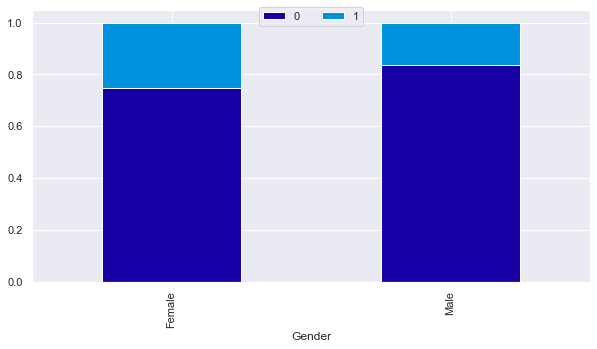

```python
stacked_plot(data["Gender"])
```

### Churned Customer vs Country

```
Exited        0     1    All
Geography
France     4204   810   5014
Germany    1695   814   2509
Spain      2064   413   2477
All        7963  2037  10000
------------------------------------------------------------------------------------------------------------------------
```

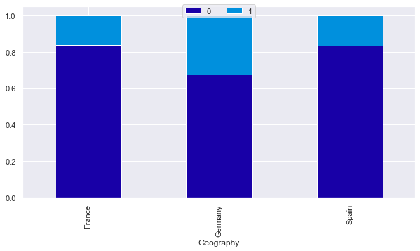

```python
stacked_plot(data["Geography"])
```

```
Exited             0     1    All
IsActiveMember
0               3547  1302   4849
1               4416   735   5151
All             7963  2037  10000
------------------------------------------------------------------------------------------------------------------------
```

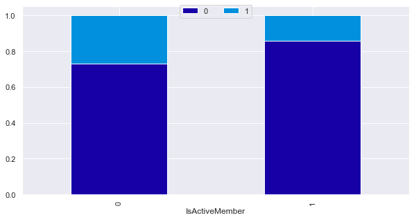

```python
stacked_plot(data["IsActiveMember"])
```

```
Exited        0     1    All
HasCrCard
0          2332   613   2945
1          5631  1424   7055
All        7963  2037  10000
------------------------------------------------------------------------------------------------------------------------
```

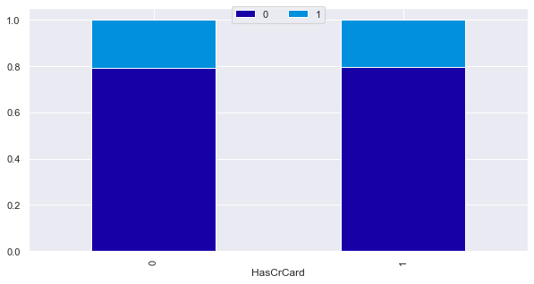

```python
stacked_plot(data["HasCrCard"])
```

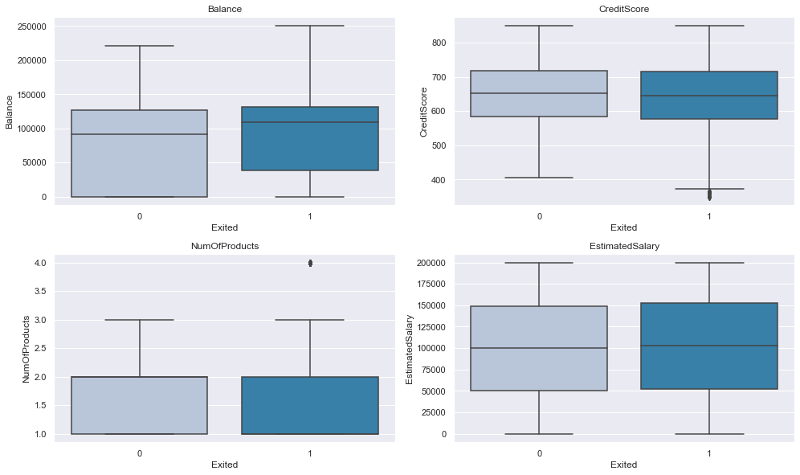

```python
# boxplot to be able to visualize various variables and the relationship with Exited

cols = data[['Balance','CreditScore','NumOfProducts','EstimatedSalary']].columns.tolist()
plt.figure(figsize=(14,12))

for i, variable in enumerate(cols):
                     plt.subplot(3,2,i+1)
                     sns.boxplot(data["Exited"],data[variable],palette="PuBu")
                     plt.tight_layout()
                     plt.title(variable)
plt.show()
```

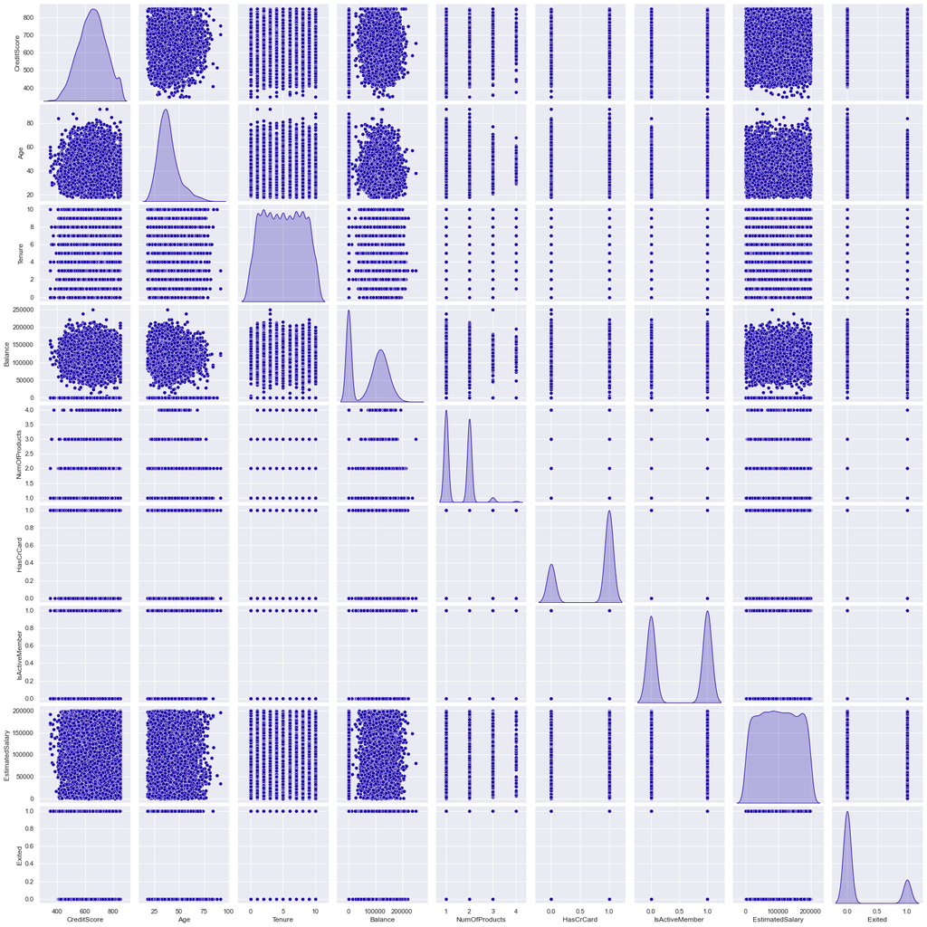

```python
# a pairpplot to observe the pariwise relationship of variables
sns.pairplot(data,diag_kind="kde")
```

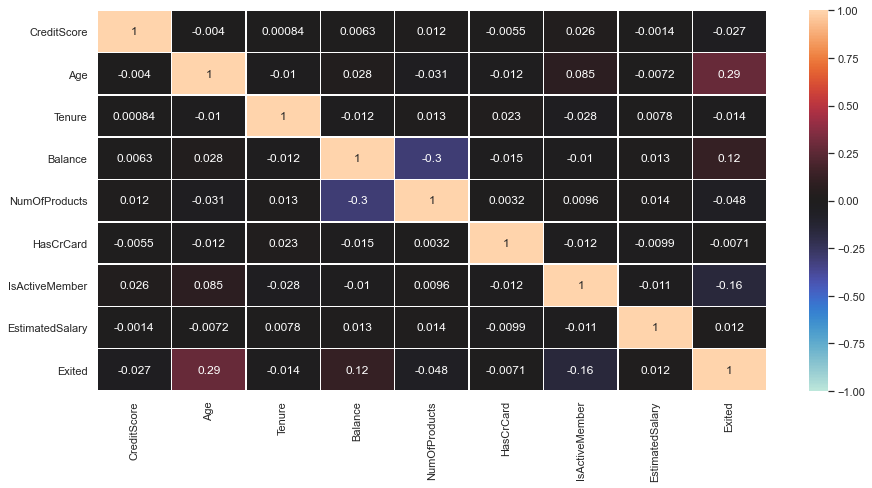

```python
plt.figure(figsize=(15,7))

sns.heatmap(data.corr(),
            annot=True,
            linewidths=0.5,vmin=-1,vmax=1,
            center=0,
            cbar=True,)

plt.show()
```

## Illustrate the insights based on EDA

#### Insights of Univariate Analysis

• Esitmated Salary - there does not appear to be any outliers. Little can be determind from the distribution, other than the data looks to be even throughout. Given this, there is little to no difference between the mean and the median.

• Majority of customers have 1 card, at 50.8% of customers. Only 0.6% of customers have 4 cards, which would be expected.

• As to whether a customer is active or not is relatively even.

#### Insights from Stack Charts & Boxplots

• Reviewing the boxplots, customers that have left the bank have a higher balance than the customers that stayed.

• Of the customers that have left the bank, there are some outliers for number of products, with some of those customers having 4 accounts with the bank.

• There does not appear to be much discrepancy between customers that stayed and left in terms of their estimated salary. Churned customers look to have a slight higher salary.

• Majority of the customers within the data are from France. However, the highest proportion of churned customers are from Germany followed by Spain. It may be possibly that the bank is having problems in areas with fewer customers. Maybe the bank are not reallocating enough customer resources to these areas.

• The proportion of female customers churning is also greater than that of male customers

• Inactive members have a greater churn. This does not come as too much of a surpirse. The bank may need a program implemented to turn this group to active customers as this will definately have a positive impact on the customer churn.

#### Data Balance & Correlations

• There is significant imbalance within the data. Roughly 80% of customers have stayed with the bank, leaving roughly 20% that have actually churned/left the bank. Working with an imbalanced data set can prove to be very challenging for building predicitve models, as it can lead to frequency bias. This means the model will learn more from the data within the majority class i.e. the customers that have not churned. Action may need to be taken when building the models in order to cater to this.

• There does not appear to be any strong correlation within the data at hand. Hoever it is worth noting some of the correlations at hand. The number of products appears to be negatively correlated with balance. There is also positive correlation between age and customers that have exited, but it is not a strong correlation.

• If there was any noticable mutilcolinearity among the independent variables, we would have to look to reassess and potentially drop additional features. When this correlation is evident it can cause a problem because independent variables should be independent of one another. If the degree of correlation between variables is high enough, it can cause problems when you fit the model and interpret the results. Howeveve, this action is not required for this analysis. In addition, there are no significant/extreme outliers among the variables, so no treatment is required.

## Data Pre-processing

#### Feature Conversion

Bothe Geography and Gender and currently categorical variables. To utilise these columns, we’ll need to use one hot encoding to convert to numerical data. Using one hot encoding, additioanl columns will be created (one for each class). However, we will take the approach of dropping the first of the newly created columns. For example, with gender there will initially be 2 columns (1 for males and 1 for females). A 1 for male will return a 0 for female and therefore there is no need for both columns. This concept also transfers to geography.

```python
#creating dummy variables for the categorical features
data_ori= data
data = pd.get_dummies(data,drop_first=True)
data = data.astype('float32') # we will need to convert the dataset to float in order to cater to tensorflow
data
```

|  | CreditScore | Age | Tenure | Balance | NumOfProducts | HasCrCard | IsActiveMember | EstimatedSalary | Exited | Geography_Germany | Geography_Spain | Gender_Male |
| --- | --- | --- | --- | --- | --- | --- | --- | --- | --- | --- | --- | --- |
| 0 | 619.0 | 42.0 | 2.0 | 0.000000 | 1.0 | 1.0 | 1.0 | 101348.882812 | 1.0 | 0.0 | 0.0 | 0.0 |
| 1 | 608.0 | 41.0 | 1.0 | 83807.859375 | 1.0 | 0.0 | 1.0 | 112542.578125 | 0.0 | 0.0 | 1.0 | 0.0 |
| 2 | 502.0 | 42.0 | 8.0 | 159660.796875 | 3.0 | 1.0 | 0.0 | 113931.570312 | 1.0 | 0.0 | 0.0 | 0.0 |
| 3 | 699.0 | 39.0 | 1.0 | 0.000000 | 2.0 | 0.0 | 0.0 | 93826.632812 | 0.0 | 0.0 | 0.0 | 0.0 |
| 4 | 850.0 | 43.0 | 2.0 | 125510.820312 | 1.0 | 1.0 | 1.0 | 79084.101562 | 0.0 | 0.0 | 1.0 | 0.0 |
| ... | ... | ... | ... | ... | ... | ... | ... | ... | ... | ... | ... | ... |
| 9995 | 771.0 | 39.0 | 5.0 | 0.000000 | 2.0 | 1.0 | 0.0 | 96270.640625 | 0.0 | 0.0 | 0.0 | 1.0 |
| 9996 | 516.0 | 35.0 | 10.0 | 57369.609375 | 1.0 | 1.0 | 1.0 | 101699.773438 | 0.0 | 0.0 | 0.0 | 1.0 |
| 9997 | 709.0 | 36.0 | 7.0 | 0.000000 | 1.0 | 0.0 | 1.0 | 42085.578125 | 1.0 | 0.0 | 0.0 | 0.0 |
| 9998 | 772.0 | 42.0 | 3.0 | 75075.312500 | 2.0 | 1.0 | 0.0 | 92888.523438 | 1.0 | 1.0 | 0.0 | 1.0 |
| 9999 | 792.0 | 28.0 | 4.0 | 130142.789062 | 1.0 | 1.0 | 0.0 | 38190.781250 | 0.0 | 0.0 | 0.0 | 0.0 |

10000 rows × 12 columns

### Separating response variable and predictors

```python
# for the probelem at hand, the variable 'Exited' is the depedent variable and so, we will seperate that from the
# independent variables.

X_data = data[['CreditScore','Age', 'Tenure', 'Balance',
     'NumOfProducts', 'HasCrCard', 'IsActiveMember', 'EstimatedSalary',
       'Geography_Germany', 'Geography_Spain', 'Gender_Male'
       ]]
y_data = data['Exited']
```

```python
#printing the shape of the data
# from printing the shape of the data we now have 11 dependent variables at hand.
print(y_data.shape)
print(X_data.shape)
```

```
(10000,)
(10000, 11)
```

### Splitting the Data into train and test set

```python
X_train, X_test, y_train, y_test = train_test_split(X_data, y_data, test_size = 0.2, random_state = 7)
```

```python
print(X_train.shape)
print(X_test.shape)
print(y_train.shape)
print(y_test.shape)
```

```
(8000, 11)
(2000, 11)
(8000,)
(2000,)
```

### Rescale the Data

Prior to developing the neural network model, we will need to scale the data. This is ensure that the variables are somewhat comparable in terms of the units measured. We want to ensure that variables with the highest units are not considered the dominant features by default. For example, in the data set the Esitmated Salary and Balance are considerably higher that some of the other variables, in terms of units measured. Differences in the scales across input variables may increase the difficulty of the problem being modeled. Large input values can result in a model that learns large weight values. A model with large weight values is often unstable, meaning that it may suffer from poor performance during learning and sensitivity to input values resulting in higher generalization error.

Scaling the data is therefore always advisable in the pre-processing stage. We will use the standardscaler() function to scale the data.

```python
#Standardizing the data
from sklearn.preprocessing import StandardScaler

# Define the scaler
scaler = StandardScaler().fit(X_train)

# Scale the train set
X_train = scaler.transform(X_train)

# Scale the test set
X_test = scaler.transform(X_test)
```

## Neural network (NN)

Model-1

We will use a simple NN made of 5 fully-connected layers with ReLu activation. The NN takes a vector of length 11 as input. This represents the information related to each variable. The final layer will output a probability distribution (sigmoid activation function) and classify either as not churned (0) or churned (1). a dropout step is included to prevent overfitting. Dropout

Dropout is a regularization technique for neural network models proposed by Srivastava, et al. in their 2014 paper Dropout: A Simple Way to Prevent Neural Networks from Overfitting. Dropout is a technique where randomly selected neurons are ignored during training. They are “dropped-out” randomly.

```python
#initialize the model
# used to create the model. We are instantiating the model here. Creates an empty model for us.
# we will begin to add layers to this model.
model = Sequential()
```

### Adding layers [layers and activations]

Keras layers can be added to the model

Adding layers are like stacking lego blocks one by one

It should be noted that as this is a classification problem, sigmoid layer (softmax for multi-class problems) should be added.

```python
# This adds the input layer (by specifying input dimension) AND the first hidden layer (units)
model.add(Dense(units=16, input_dim = 11,activation='relu'))   # input of 11 columns as shown above
# hidden layer
model.add(Dense(units=24,activation='relu'))
#Adding Dropout to prevent overfitting
model.add(Dropout(0.5))
model.add(Dense(24,activation='relu'))
model.add(Dense(24,activation='relu'))
# Adding the output layer
# Notice that we do not need to specify input dim.
# we have an output of 1 node, which is the the desired dimensions of our output (exit or not)
# We use the sigmoid because we want probability outcomes
model.add(Dense(1,activation='sigmoid'))                        # binary classification exit or not
```

#### Model compile [optimizers and loss functions]

Keras model should be "compiled" prior to training

Types of loss (function) and optimizer should be designated

```python
# Create optimizer with default learning rate
# We want to minimize the loss function. Here we are using binary cross entropy as we just have 2 classes.
#In order to minimize this loss we define the function we want to make use of. Here he uses adam - This is the optimizer function.
# this is what drives you to absolute minimum of the error function. There are various types of optimizer functions we could use.
# using different hyper parameter functions will allow us to determine better results.
# the metric we want to use is the accuracy score.
# Compile the model
model.compile(optimizer='adam',loss='binary_crossentropy',metrics=['accuracy'])
```

### Let's print the summary of the model

```python
model.summary()
```

```
Model: "sequential"
_________________________________________________________________
Layer (type)                 Output Shape              Param #
=================================================================
dense (Dense)                (None, 16)                192
_________________________________________________________________
dense_1 (Dense)              (None, 24)                408
_________________________________________________________________
dropout (Dropout)            (None, 24)                0
_________________________________________________________________
dense_2 (Dense)              (None, 24)                600
_________________________________________________________________
dense_3 (Dense)              (None, 24)                600
_________________________________________________________________
dense_4 (Dense)              (None, 1)                 25
=================================================================
Total params: 1,825
Trainable params: 1,825
Non-trainable params: 0
_________________________________________________________________
```

### Training [Forward pass and Backpropagation]

Training the model

While training the model we will make use of additioanl hyperparameters that are used in forward pass and backpropagation learning algorithm.

There parameters are:

Batches: this refers to the number of samples we decide to split the data into, prior to updating the internal model parameters. The batch is commonly completed while training the model. At the end of the batch, the predictions are compared to the expected output variables and an error is calculated. From this error, the update algorithm is used to improve the model, e.g. move down along the error gradient. Common batch sizes used are 16, 32, 64.

Epochs: the number of epochs defined refers to number of times the learning algorithm will work through the entire training dataset. For each epoch defined the model has oppurtuniy to update the internal model parameters and learn from the data. As the validation loss decreases for each epoch defined, this implies that the model is improving and learning from the data. Given this, it is common for there to be a large number of epochs deinfed (from hundreds to thousands).

```python
#fitting the model
# here we define additional hyper parameters, which are the batch and the epochs
# batch -
history=model.fit(X_train,y_train,batch_size=15,epochs=10,validation_split=0.2)
```

### Plotting the train and Valiation loss

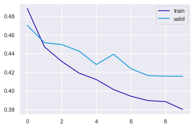

```python
# Capturing learning history per epoch
hist  = pd.DataFrame(history.history)
hist['epoch'] = history.epoch

# Plotting accuracy at different epochs
plt.plot(hist['loss'])
plt.plot(hist['val_loss'])
plt.legend(("train" , "valid") , loc =0)
```

### Evaluation¶

Keras model can be evaluated with evaluate() function

Evaluation results are contained in a list

```python
score = model.evaluate(X_test, y_test)
```

```python
print(score)
```

```
[0.40753400325775146, 0.8335000276565552]
```

## Model Performance Improvement

Comment on which metric is right for model performance evaluation and why? - Find the optimal threshold using ROC-AUC or Precision-Recall curves - Comment on model performance - Can model performance be improved? check and comment - Build another model to implement these improvements - Include all the model which were trained to reach at the final one

### Model evaluation criterion

The main concern to the bank is a model that will make incorrect predictions. There are 2 primary incorrect predictions that the model can make.

#### Model can make wrong predictions as:

1. Predicting a customer will leave and the customer does not leave
2. Predicting a customer will not leave and the customer does in fact leave the bank

#### Which case is more important?

The main loss to the the bank would be a model that predicts that the customer will not leave the bank but they do in fact leave. The overall result to the bank would be a loss of customers and hence a loss of income to the bank. In the case that the customer does not leave, this would not result in a substantial loss of income, as the individual would still be a customer for the bank. Therefore, given that the bank is concerned are being able to correctly predict when a customer will leave the bank, they will want to reduce the number of false negatives.

#### How to reduce this loss i.e need to reduce False Negative?

The bank would want Recall to be maximized. The greater the recall the higher the chances of minimizing false negatives (and maximizing true positives). Hence, the focus should be on increasing recall and minimizing the false negatives or in other words identifying the True Positives(i.e. the bank can better identify the customers the will leave the bank).

#### We will define a confusion matrix function that will allow us to easily compute the performance results across different models

```python
def make_confusion_matrix(cf,
                          group_names=None,
                          categories='auto',
                          count=True,
                          percent=True,
                          cbar=True,
                          xyticks=True,
                          xyplotlabels=True,
                          sum_stats=True,
                          figsize=None,
                          cmap='Blues',
                          title=None):
    '''
    This function will make a pretty plot of an sklearn Confusion Matrix cm using a Seaborn heatmap visualization.
    Arguments
    '''


    # CODE TO GENERATE TEXT INSIDE EACH SQUARE
    blanks = ['' for i in range(cf.size)]

    if group_names and len(group_names)==cf.size:
        group_labels = ["{}\n".format(value) for value in group_names]
    else:
        group_labels = blanks

    if count:
        group_counts = ["{0:0.0f}\n".format(value) for value in cf.flatten()]
    else:
        group_counts = blanks

    if percent:
        group_percentages = ["{0:.2%}".format(value) for value in cf.flatten()/np.sum(cf)]
    else:
        group_percentages = blanks

    box_labels = [f"{v1}{v2}{v3}".strip() for v1, v2, v3 in zip(group_labels,group_counts,group_percentages)]
    box_labels = np.asarray(box_labels).reshape(cf.shape[0],cf.shape[1])


    # CODE TO GENERATE SUMMARY STATISTICS & TEXT FOR SUMMARY STATS
    if sum_stats:
        #Accuracy is sum of diagonal divided by total observations
        accuracy  = np.trace(cf) / float(np.sum(cf))

        #if it is a binary confusion matrix, show some more stats
        if len(cf)==2:
            #Metrics for Binary Confusion Matrices
            precision = cf[1,1] / sum(cf[:,1])
            recall    = cf[1,1] / sum(cf[1,:])
            f1_score  = 2*precision*recall / (precision + recall)
            stats_text = "\n\nAccuracy={:0.3f}\nPrecision={:0.3f}\nRecall={:0.3f}\nF1 Score={:0.3f}".format(
                accuracy,precision,recall,f1_score)
        else:
            stats_text = "\n\nAccuracy={:0.3f}".format(accuracy)
    else:
        stats_text = ""


    # SET FIGURE PARAMETERS ACCORDING TO OTHER ARGUMENTS
    if figsize==None:
        #Get default figure size if not set
        figsize = plt.rcParams.get('figure.figsize')

    if xyticks==False:
        #Do not show categories if xyticks is False
        categories=False


    # MAKE THE HEATMAP VISUALIZATION
    plt.figure(figsize=figsize)
    sns.heatmap(cf,annot=box_labels,fmt="",cmap=cmap,cbar=cbar,xticklabels=categories,yticklabels=categories)

    if xyplotlabels:
        plt.ylabel('True label')
        plt.xlabel('Predicted label' + stats_text)
    else:
        plt.xlabel(stats_text)

    if title:
        plt.title(title)
```

### Print the Confusion Matrix for the Neural Network

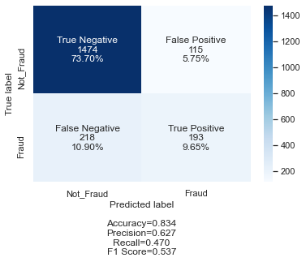

```python
## Confusion Matrix on unsee test set
import seaborn as sn
y_pred1 = model.predict(X_test)
for i in range(len(y_test)):
    if y_pred1[i]>0.5:
        y_pred1[i]=1
    else:
        y_pred1[i]=0



cm2=confusion_matrix(y_test, y_pred1)
labels = ['True Negative','False Positive','False Negative','True Positive']
categories = [ 'Not_Fraud','Fraud']
make_confusion_matrix(cm2,
                      group_names=labels,
                      categories=categories,
                      cmap='Blues')
```

### Auc-ROC Curve & Optimal Threshold

We will use the AUD-ROC curve to further evaluate the performance of the model and help determine the optimal threshold to use.

The AUC - ROC curve is a performance measurement that is used for classification problems. The ROC is the probibility curve and the AUC measures the degree of separability of classes. It tells how much the model is capable of distinguishing between classes. The higher the AUC the better the performance of the model, as it allows us to conclude that the model is good at distinguishing betweem each class. The y-axis is the True Positive Rate or the Recall and the x-axis is the False postive rate.

The curve will be built using a range of thresholds on the test set, creating the ROC Curve. We can see that there are a number of points or thresholds close to the top-left of the plot. Determining the optimal threshold will then be required. Determining the optimial threshold can be difficult as there may be various similar thresholds. We will use the geometric mean or known as G-mean to help determine this. The G-Mean is the gerometric mean of Specificity /recall and Sensitivity (true postiives). It is considered to be an unbiased metric for imbalanced classifications, which is what we are currently presented with.

```python
# Import performance metrics from sklearn
from sklearn.metrics import confusion_matrix,accuracy_score, roc_curve, auc
%matplotlib inline
from plotnine import *
import plotnine
```

```python
#Predict on test set
predictions_NN_prob = model.predict(X_test)
predictions_NN_prob = predictions_NN_prob[:,0]

predictions_NN_01 = np.where(predictions_NN_prob > 0.5217, 1, 0) #Turn probability to 0-1 binary output
```

```python
#Print accuracy
acc_NN = accuracy_score(y_test, predictions_NN_01)
print('Overall accuracy of Neural Network model:', acc_NN)
```

```
Overall accuracy of Neural Network model: 0.8365
```

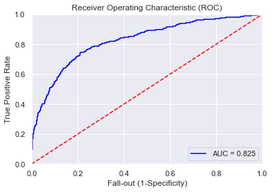

```python
#Print Area Under Curve
false_positive_rate, true_postitive_rate, thresholds = roc_curve(y_test, predictions_NN_prob)
roc_auc = auc(false_positive_rate, true_postitive_rate)
df_fpr_tpr = pd.DataFrame({'FPR':false_positive_rate, 'TPR':true_postitive_rate, 'Threshold':thresholds})
plt.figure()
plt.title('Receiver Operating Characteristic (ROC)')
plt.plot(false_positive_rate,  true_postitive_rate, 'b', label = 'AUC = %0.3f' %roc_auc)
plt.legend(loc='lower right')
plt.plot([0,1], [0,1], 'r--')
plt.xlim([0.0,1.0])
plt.ylim([0.0,1.0])
plt.ylabel('True Positive Rate')
plt.xlabel('Fall-out (1-Specificity)')
plt.show()
```

```
Best Threshold: 0.2838999927043915 with G-Mean: 0.7665
FPR: 0.2108, TPR: 0.7445
```

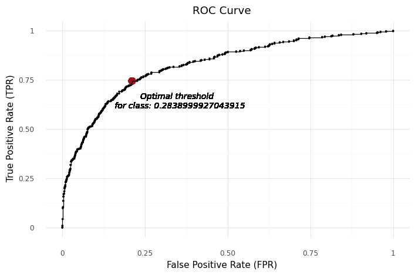

```python
# Calculate the G-mean
gmean = np.sqrt(true_postitive_rate * (1 - false_positive_rate))

# Find the optimal threshold
index = np.argmax(gmean)
thresholdOpt = round(thresholds[index], ndigits = 4)
gmeanOpt = round(gmean[index], ndigits = 4)
fprOpt = round(false_positive_rate[index], ndigits = 4)
tprOpt = round(true_postitive_rate[index], ndigits = 4)
print('Best Threshold: {} with G-Mean: {}'.format(thresholdOpt, gmeanOpt))
print('FPR: {}, TPR: {}'.format(fprOpt, tprOpt))

# Create data viz
plotnine.options.figure_size = (8, 4.8)
(
    ggplot(data = df_fpr_tpr)+
    geom_point(aes(x = 'FPR',
                   y = 'TPR'),
               size = 0.4)+
    # Best threshold
    geom_point(aes(x = fprOpt,
                   y = tprOpt),
               color = '#981220',
               size = 4)+
    geom_line(aes(x = 'FPR',
                  y = 'TPR'))+
    geom_text(aes(x = fprOpt,
                  y = tprOpt),
              label = 'Optimal threshold \n for class: {}'.format(thresholdOpt),
              nudge_x = 0.14,
              nudge_y = -0.10,
              size = 10,
              fontstyle = 'italic')+
    labs(title = 'ROC Curve')+
    xlab('False Positive Rate (FPR)')+
    ylab('True Positive Rate (TPR)')+
    theme_minimal()
)
```

### Comment on Model Performance

#### Train and Valiation loss

Evidence of overfitting is evident from the training loss. Referring to the graph, the training loss continues to decrease sharply att the end. In addition, the validation loss is higher than the training loss and there are fluctuations with the validation loss. These are all evidence that our model is overfitting.

#### Confusion Matrix Insights

Looking at the results of the neural network, the model has a realtively low recall (47%)and a higher percentage of false negtives than than True postives. Given that we are looking to maximize the recall and hence minmize the false negatives the results of the neural model are relatively poor.

The initial poor results are driven by the high imbalance that we initially have discussed within the data. Roughly 80% of the customers have stayed with the bank, and 0 is the dominant classe i.e. a customer that has not left. Thus, this can and has led to overfitting of the dominant class at the training stage.

There ar various methods that can be used to deal with the imbalnce of a data set, such as resampling the data (using SMOTE upsampling and downsampling methods), as well as developing customized versions of the algorithm. However, one of the more simply approach is to change the decsion threshold. Using the AUC_ROC is one method as such, as already discussed. The plot summarizes the behavior of a model by calculating the false positive rate and true positive rate for a set of predictions by the model under different thresholds. Each threshold is a point on the plot and the points are connected to form a curve. A classifier that has no skill (e.g. predicts the majority class under all thresholds) will be represented by a diagonal line from the bottom left to the top right.

#### Insights from the AUC-ROC Curve

• When looking at the AUC-ROC curve, our main concern is the area under the curve. With an AUC of 0.825 this could be considered realtively good results, as this implies that the model is good at differentiating between customers that have churned and customers that have stayed i.e. 82.5% chance the model will be able to distinguish between the 2.

### Conclusion:

Let's see if we can improve this performance with other machine learning / deep learning models in the rest of the notebook.

## Model Improvements

#### Let's try another architecture to get the better Recall

There are some basic Hyperparameters which can help to get the better model performance.

### Early stopping:

As previously mentioned there is evidence of overfitting given the results of the validations loss (there are decreases followed by increases within the graph). Early stopping is a method that can help deal with this.

During training, the model is evaluated on a holdout validation dataset after each epoch. If the performance of the model on the validation dataset starts to degrade or there is no improvement (e.g. loss begins to increase or accuracy begins to decrease), then the training process is stopped after the certian amount of interations. The model at the time that training is stopped is then used and is known to have good generalization performance.

This procedure is called “early stopping” and is perhaps one of the oldest and most widely used forms of neural network regularization.

### Weight Initialization

Weight initialization is an important consideration in the design of a neural network model.

The nodes in neural networks are composed of parameters referred to as weights used to calculate a weighted sum of the inputs.

Neural network models are fit using an optimization algorithm called stochastic gradient descent that incrementally changes the network weights to minimize a loss function, hopefully resulting in a set of weights for the node that is capable of making useful predictions.

This optimization algorithm requires a starting point in the space of possible weight values from which to begin the optimization process. Weight initialization is a procedure to set the weights of a neural network to small random values that define the starting point for the optimization (learning or training) of the neural network model.

There are many WI techniques as follows:

1) Random normal initialization

2) Random Uniform initialization

3) Xaviour Initialization

4) He Initialization

### Early Stopping Neural Network

```python
#Training Multi-layer perceptron with 2 hidden layers

#adding earlystopping callback
es= keras.callbacks.EarlyStopping(monitor='val_loss',
                              min_delta=0,
                              patience=15,

                             verbose=0, mode='min', restore_best_weights= True)

Model2 = Sequential()
#Initializing the weights uisng hue_normal
Model2.add(Dense(65, input_shape=(11, ), kernel_initializer='he_normal', activation='relu'))
Model2.add(Dropout(0.5))
Model2.add(Dense(65, kernel_initializer='he_normal', activation='relu'))
Model2.add(Dropout(0.5))
Model2.add(Dense(1, kernel_initializer='he_normal', activation='sigmoid'))

Model2.compile(Adam(lr=0.001), loss='binary_crossentropy', metrics=['accuracy'])

his_mod2= Model2.fit(X_train, y_train, validation_split=0.2, batch_size=700, epochs=40, callbacks=[es], shuffle=True, verbose=1)
```

Plotting the train and validation loss

#### Learning History for Early Stopping Model

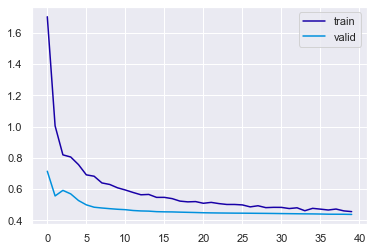

```python
# Capturing learning history per epoch
hist  = pd.DataFrame(his_mod2.history)
hist['epoch'] = his_mod2.epoch

# Plotting accuracy at different epochs
plt.plot(hist['loss'])
plt.plot(hist['val_loss'])
plt.legend(("train" , "valid") , loc =0)
```

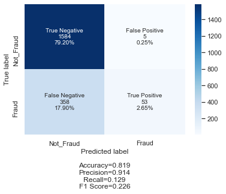

```python
## Confusion Matrix on unsee test set
import seaborn as sn
y_pred1 = Model2.predict(X_test)
for i in range(len(y_test)):
    if y_pred1[i]>0.5:
        y_pred1[i]=1
    else:
        y_pred1[i]=0



cm2=confusion_matrix(y_test, y_pred1)
labels = ['True Negative','False Positive','False Negative','True Positive']
categories = [ 'Not_Fraud','Fraud']
make_confusion_matrix(cm2,
                      group_names=labels,
                      categories=categories,
                      cmap='Blues')
```

### Insights:

Let's try weighted loss for imbalance dataset

### Weighted loss to account for large class imbalance in train dataset

We will adjust the class imbalance by giving additional weight to the loss associated to errors made on churned customers. We will use our first ANN model and apply weighted loss

Let's review the process:

```python
from sklearn.utils import class_weight
class_weights = class_weight.compute_class_weight('balanced', np.unique(y_train), np.array([y_train.iloc[i] for i in range(len(y_train))]))
class_weights = dict(enumerate(class_weights))
class_weights
```

```
{0: 0.627549419516787, 1: 2.4600246002460024}
```

The class 'Exited' (y=1) is assigned a weight of 2.46 vs 0.627 for the class 'Not Exited' due to the very low prevalence we detected during data exploration. This allows the model to give more importance to the errors made on fraudulent cases during training.

```python
model.fit(X_train,y_train,batch_size=16,epochs=20, class_weight=class_weights, shuffle=True)
```

```
<tensorflow.python.keras.callbacks.History at 0x1e02d4410a0>
```

```python
score_weighted = model.evaluate(X_test, y_test)
```

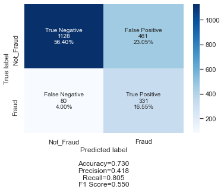

```python
## Confusion Matrix on unsee test set
import seaborn as sn
y_pred1 = model.predict(X_test)
for i in range(len(y_test)):
    if y_pred1[i]>0.5:
        y_pred1[i]=1
    else:
        y_pred1[i]=0



cm2=confusion_matrix(y_test, y_pred1)
labels = ['True Negative','False Positive','False Negative','True Positive']
categories = [ 'Not_Fraud','Fraud']
make_confusion_matrix(cm2,
                      group_names=labels,
                      categories=categories,
                      cmap='Blues')
```

### Hyper Paramter Tuning

• Finding the optimal batch and epcoh hyper-parameter values to use can be difficult. The goal is to continuously minimize the loss. For our case at hand, we want the model that will minmize this loss, so that we can maximize the recall and minimize the false negatives.

• To find the optimal model use trial and error using different hyperparameter values and see what are the optimal results.

```python
model.fit(X_train,y_train,batch_size=16,epochs=64, class_weight=class_weights, shuffle=True)
```

```
<tensorflow.python.keras.callbacks.History at 0x1e02eb583d0>
```

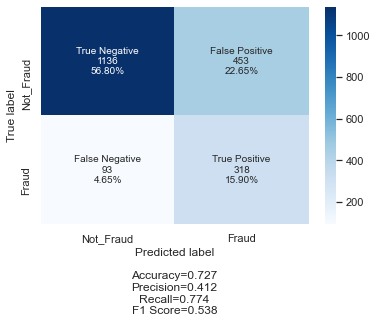

```python
## Confusion Matrix on unsee test set
import seaborn as sn
y_pred1 = model.predict(X_test)
for i in range(len(y_test)):
    if y_pred1[i]>0.5:
        y_pred1[i]=1
    else:
        y_pred1[i]=0



cm2=confusion_matrix(y_test, y_pred1)
labels = ['True Negative','False Positive','False Negative','True Positive']
categories = [ 'Not_Fraud','Fraud']
make_confusion_matrix(cm2,
                      group_names=labels,
                      categories=categories,
                      cmap='Blues')
```

```python
model.fit(X_train,y_train,batch_size=32,epochs=100, class_weight=class_weights, shuffle=True)
```

```
<tensorflow.python.keras.callbacks.History at 0x1e02d87a3a0>
```

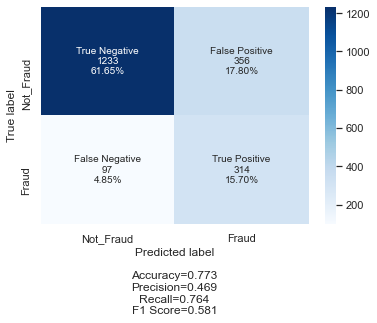

```python
## Confusion Matrix on unsee test set
import seaborn as sn
y_pred1 = model.predict(X_test)
for i in range(len(y_test)):
    if y_pred1[i]>0.5:
        y_pred1[i]=1
    else:
        y_pred1[i]=0



cm2=confusion_matrix(y_test, y_pred1)
labels = ['True Negative','False Positive','False Negative','True Positive']
categories = [ 'Not_Fraud','Fraud']
make_confusion_matrix(cm2,
                      group_names=labels,
                      categories=categories,
                      cmap='Blues')
```

• Increaing the batch size in conjunction with the epoch actually resulted in worse results. We have a lower recall than the model with a batch size of 16 and an epoch of 64.

• As previously discussed the epoch allows the model to learn and for each iteration we are hoping for a reductions in the validation loss. We will therefore look to reduce the batch size and increase the epoch to see if this provides better results.

```python
model.fit(X_train,y_train,batch_size=8,epochs=500, class_weight=class_weights, shuffle=True)
```

```
<tensorflow.python.keras.callbacks.History at 0x1e02d6a37f0>
```

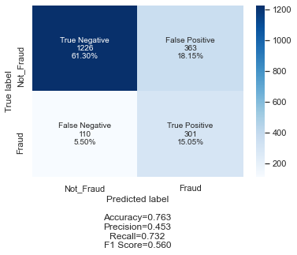

```python
## Confusion Matrix on unsee test set
import seaborn as sn
y_pred1 = model.predict(X_test)
for i in range(len(y_test)):
    if y_pred1[i]>0.5:
        y_pred1[i]=1
    else:
        y_pred1[i]=0



cm2=confusion_matrix(y_test, y_pred1)
labels = ['True Negative','False Positive','False Negative','True Positive']
categories = [ 'Not_Fraud','Fraud']
make_confusion_matrix(cm2,
                      group_names=labels,
                      categories=categories,
                      cmap='Blues')
```

```python
model.fit(X_train,y_train,batch_size=8,epochs=1000, class_weight=class_weights, shuffle=True)
```

```
<tensorflow.python.keras.callbacks.History at 0x1e02d64b8b0>
```

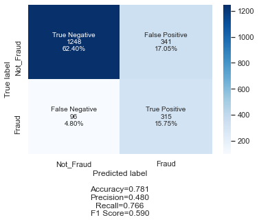

```python
## Confusion Matrix on unsee test set
import seaborn as sn
y_pred1 = model.predict(X_test)
for i in range(len(y_test)):
    if y_pred1[i]>0.5:
        y_pred1[i]=1
    else:
        y_pred1[i]=0



cm2=confusion_matrix(y_test, y_pred1)
labels = ['True Negative','False Positive','False Negative','True Positive']
categories = [ 'Not_Fraud','Fraud']
make_confusion_matrix(cm2,
                      group_names=labels,
                      categories=categories,
                      cmap='Blues')
```

```python
model.fit(X_train,y_train,batch_size=8,epochs=100, class_weight=class_weights, shuffle=True)
```

```
<tensorflow.python.keras.callbacks.History at 0x1e02eb58700>
```

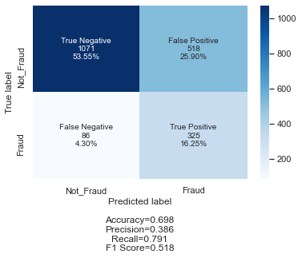

```python
## Confusion Matrix on unsee test set
import seaborn as sn
y_pred1 = model.predict(X_test)
for i in range(len(y_test)):
    if y_pred1[i]>0.7161:
        y_pred1[i]=1
    else:
        y_pred1[i]=0



cm2=confusion_matrix(y_test, y_pred1)
labels = ['True Negative','False Positive','False Negative','True Positive']
categories = [ 'Not_Fraud','Fraud']
make_confusion_matrix(cm2,
                      group_names=labels,
                      categories=categories,
                      cmap='Blues')
```

## Model Performance Evaluation

- Evaluate the model on different performance metrics and comment on the performance and scope of improvement

Initially, as previously discussed there was significant imbalance in the data, with roughly 80% of customers havings stayed with the bank. Therefore without treating this imbalance, the outcome is going to be biased towards the dominant class. The use of weighted loss places more importance on the less dominant class i.e. churned customers in this case. The class 'Exited' (y=1) is assigned a weight of 2.46 vs 0.627 for the class 'Not Exited' due to the very low prevalence we detected during data exploration. This allows the model to give more importance to the errors made on churned customers during training.

Taking this approach reduces the chances of bias significantly. However, despite the recall having improved, the precision is still quite low, with a high percentage of false positives. Despite precision not being the primary metric of concern, further evaluation and testing would be advised in order to assess if futher improvements could be made. Precison should not be considered a useless metric, as it is still of importance for the bank. For example, if the bank were to predict a high percentage of customers would churn, but they stayed, customer satisfaction be be low. This may be due to the bank not being very engaged with these customers and not providing any new promotions to these customers. In the future, customer disatisfaction may result in the customers leaving. As mentioned in EDA, France has the highest amount of customers. However, both Spain & Germany have a higher percentage of their customers exiting the bank. Customer satisfaction and further engagement from the bank, may be an advisable scope for improvement in these areas.

On the contrary, if the bank were to predict that a high percentage of customers will leave the bank, they may actually waist resources trying to convinve these customers to stay with the bank.

#### Further Improvements

Different forms of hyper parmeter tuning could be used, with various other types of models e.g. Random Forests, Decision Trees and other forms of Ensemble techniques. Further hyper parameter tuning on these models, utilizing hyper parameters such as min sample leaf, max features and max samples, would be advisable.

While we did look to cater to the imbalance of the data using weighted loss, other approachs such as resampling the data could have been take. Using Synthetic Minority Oversampling Techniques (SMOTE), such as upsampling and downsampling are examples of appraoches that could be taken.

While implementing other methods and revaluating the performance on these new models is advised, implmenting some of these techniques is computationally exhaustive. We therefore will not be implemeting them for the purpose of this assignement. Additional approaches would be recommended for hypertuning the models that we have developed, to see if improvements could be made. However, there is no direct way to calculate how a change in the hyperparameter value will reduce the loss of your model until you try those hyperparameters. Therefore additional testing would be advised, but not for this project given the time on our hands.

## Conclusion:

Overall, we did manage to improve the performance of the model. We have improved the ability for for the model to correctly predict customers that will exit the bank. From our results the Recall has increased but the precision is quite low. There is still lot of scope of improvements as follows:

2) Resampling techniques can be applied to balanced the data and then train the model

3) Hyperparameter tuning can be applied to tune the different Hyperparameters

We can select the weighted loss model as our model of best fit. With some hyperparameter tuning, we were able to further improve the performance of this model. However, additional training, different forms of resampling and even analysing with different models would be advised.

Lastly, we have based the performance of these models purely around recall. For a bank being to identify the customers who will churn, versus those that will not churn, is deemed the best metric to use. However, precision is a metric that should not be perceived as useless. Reason being, the bank may spend and waist a lot of resources on customers that will predict will churn, but they in fact stay with the bank.